# Coursera Reproducible Research - Assessment 2

# 3 Results

The purpose of the above data processing has been to ask and answer the following questions:

- Across the United States, which types of events (as indicated in the eventType variable) are most harmful with respect to population health?
- Across the United States, which types of events have the greatest economic consequences?

## 3.1 Events most harmful to population Health

```r
# Display Population impact of the top 10 events.
print(xtable(head(eventImpactSummary, n = 10),
             caption = c("Events most harmful with respect to population",
                         "Event impact on Population")),
      digits = c(0,0,0,0,0,0,2),
      comment = F,
      type="html",
      include.rownames = F)
```

Events most harmful with respect to population

| eventType | eventFatalities | eventInjuries | eventCount | popImpacted | eventFreq |
| --- | --- | --- | --- | --- | --- |
| TORNADO | 5636.00 | 91407.00 | 60699 | 97043.00 | 1.60 |
| WIND | 1451.00 | 11498.00 | 364901 | 12949.00 | 0.04 |
| HEAT | 3138.00 | 9224.00 | 2648 | 12362.00 | 4.67 |
| FLOOD | 1524.00 | 8604.00 | 82686 | 10128.00 | 0.12 |
| LIGHTNING | 817.00 | 5231.00 | 15760 | 6048.00 | 0.38 |
| FIRE | 90.00 | 1608.00 | 4239 | 1698.00 | 0.40 |
| HURRICANE | 133.00 | 1328.00 | 287 | 1461.00 | 5.09 |
| HAIL | 15.00 | 1371.00 | 289276 | 1386.00 | 0.00 |
| SNOW | 164.00 | 1123.00 | 17682 | 1287.00 | 0.07 |
| BLIZZARD | 101.00 | 805.00 | 2725 | 906.00 | 0.33 |

[figure not shown]

```r
## Plot mostDangerous Events, sized by frequency
options(scipen=999)
gp <- ggplot(head(eventImpactSummary, n = 10),
             aes(x=eventFatalities,
                 y=eventInjuries,
                 color=eventType,
                 label = eventType,
                 xmin = -1000,
                 ymin = -5000,
                 ymax = eventInjuries + 1000
                 ))
gp <- gp + theme_wsj() + theme(axis.title = element_text(size = 12))
gp <- gp + theme(axis.title.y = element_text(angle = 90))
gp <- gp + geom_point(aes(size = eventCount))
gp <- gp + scale_size_area(max_size=20)
gp <- gp + geom_point(size = 5) + geom_text(size = 4, hjust = .7, vjust = 3 )
gp <- gp + theme(axis.text=element_text(size=12),
                 axis.title=element_text(size=14,face="bold"),
                 plot.title = element_text(face="bold"))
gp <- gp + xlab(paste0("\n","Total Injuries"))
gp <- gp + ylab(paste0("Total Fatalities","\n"))
gp <- gp + ggtitle("Events most harmful with respect to population\n")
print(gp)
```

## 3.2 Events most harmful to property

```r
# Display proprtyDamage impact of the top 10 events.
print(xtable(head(propertyDamageSummary, n = 10),
             caption = c("Events most harmful with respect to property",
                         "Event impact on property")),
      digits = c(0,0,0,0,0,0,0,0),
      comment = F,
      type="html",
      include.rownames = F)
```

Events most harmful with respect to property

| eventType | propertyDamage | cropDamage | eventCount | totalDamage | eventFreq |
| --- | --- | --- | --- | --- | --- |
| FLOOD | 167502193929.30 | 12266906100.00 | 82686 | 179769100029.30 | 2174117.75 |
| HURRICANE | 84656180010.00 | 5505292800.00 | 287 | 90161472810.00 | 314151473.21 |
| TORNADO | 56993098028.70 | 414961520.00 | 60699 | 57408059548.70 | 945782.62 |
| STORM SURGE | 47964724000.00 | 855000.00 | 409 | 47965579000.00 | 117275254.28 |
| WIND | 17742581051.61 | 2159304538.00 | 364901 | 19901885589.61 | 54540.51 |
| HAIL | 15974043047.70 | 3046837473.00 | 289276 | 19020880520.70 | 65753.40 |
| FIRE | 8496628500.00 | 403281630.00 | 4239 | 8899910130.00 | 2099530.58 |
| TROPICALSTORM | 7716127550.00 | 694896000.00 | 757 | 8411023550.00 | 11110995.44 |
| RAIN | 3255831192.00 | 806505800.00 | 12267 | 4062336992.00 | 331159.78 |
| FREEZING | 21512000.00 | 1889061000.00 | 1515 | 1910573000.00 | 1261104.29 |

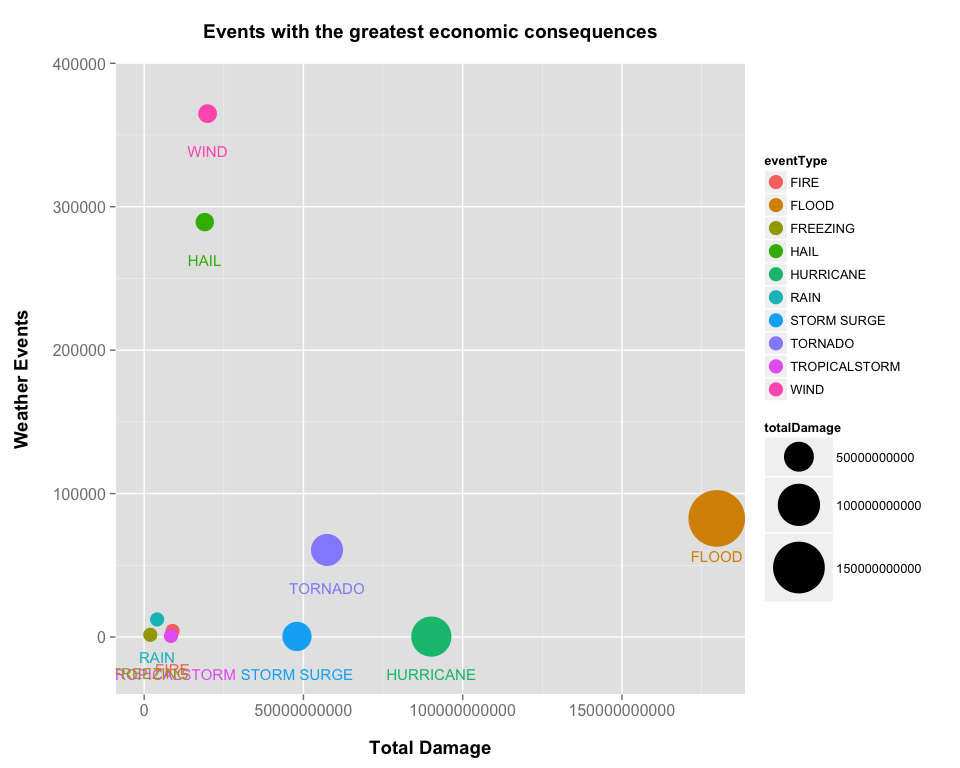

```r
gp <- ggplot(head(propertyDamageSummary, n = 10),
             aes(x=totalDamage,
                 y=eventCount,
                 color=eventType,
                 label = eventType,
                 xmin = -1000,
                 ymin = -20000,
                 xmax = 110000000000,
                 ymax = 380000 ))
gp <- gp + geom_point(aes(size = totalDamage))
gp <- gp + scale_size_area(max_size=20)
gp <- gp + geom_point(size = 5) + geom_text(size = 4, hjust = .5, vjust = 4 )
gp <- gp + theme(axis.text=element_text(size=12),
                 axis.title=element_text(size=14,face="bold"),
                 plot.title = element_text(face="bold"))
gp <- gp + xlab(paste0("\n","Total Damage"))
gp <- gp + ylab(paste0("Weather Events","\n"))
gp <- gp + ggtitle("Events with the greatest economic consequences\n")
print(gp)
```

# 4 References

- [NOAA](http://www.noaa.gov/)
- [NOAA Event Database Website](http://www.ncdc.noaa.gov/stormevents/details.jsp?type=collection)
- [National Weather Service Storm Data Documentation](https://d396qusza40orc.cloudfront.net/repdata%2Fpeer2_doc%2Fpd01016005curr.pdf)
- [National Climatic Data Center Storm Events FAQ](https://d396qusza40orc.cloudfront.net/repdata%2Fpeer2_doc%2FNCDC%20Storm%20Events-FAQ%20Page.pdf)
- *R in Action*
  - By: Robert Kabacoff Publisher: Manning Publications Pub. Date: August 24, 2011, ISBN-10: 1-935182-39-0
- *Mathematical Statistics with Resampling and R*
  - By: Laura Chihara; Tim Hesterberg Publisher: John Wiley & Sons Pub. Date: September 6, 2011 Print ISBN: 978-1-11-02985-5
- *Think Stats, 2nd Edition*
  - By: Allen B. Downey Publisher: O’Reilly Media, Inc. Pub. Date: October 28, 2014 Print ISBN-13: 978-1-4919-0733-7